# Why Do Firms Exist?

Stephen Weymouth

Dean’s Professor

2026-09-21

# Apple outsources memory and other components, but does R&D internally.

## Your IB Voice

Your explanation

Apple designs the chips in its iPhones but buys the memory inside them from Samsung, a competitor. Why do you think Apple does one itself and buys the other?

**10 minutes**

## Competing explanations

Why would a firm do something itself rather than buy it?

Control: quality and timing are easier to command than to negotiate.

Secrets: know-how is safer inside than in a supplier’s hands.

Cost: a supplier’s price carries the supplier’s margin.

Dependence: a supplier you cannot replace can squeeze you.

What evidence would help us tell these apart?

# Why Do Firms Exist?

## Coase’s question: which tasks go inside, and why?

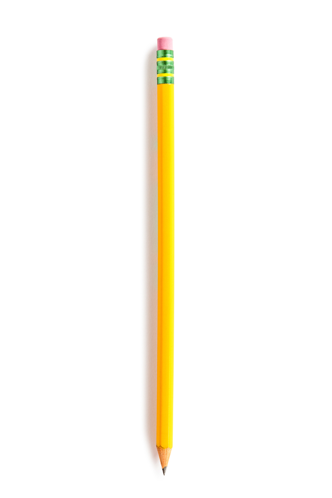

Leonard E. Read, “I, Pencil” (1958), the first day’s pencil · Online Library of Liberty.

Many firms made the pencil, each buying what it did not make.

Apple buys memory at a price. It does not buy an engineer’s time for an afternoon; it employs her and directs her.

If prices work for memory, why not for design? If direction works for design, why not for memory?

Coase’s answer: using prices is not free. Every exchange means finding the price and writing a contract. Where that costs more than having a manager decide, the work moves inside a firm (and the firm gets larger).

## Apple draws its line in a particular place

Inside: chip, hardware, and software design; the stores; the Irish and Nevada subsidiaries.

Bought: memory from Samsung, SK Hynix, and Micron; fabrication from TSMC; displays and parts.

[figure not shown]

Sonic8400, [iPhone 5s logic board with A7](https://commons.wikimedia.org/wiki/File:A7_APL0698_iPhone5s_mlb_820-3292-A.jpg), 2020 · Wikimedia Commons, CC BY-SA 4.0.

## Using the market costs something at every step

[figure not shown]

Jorge Franganillo, Grand Bazaar, Istanbul · Wikimedia Commons, CC BY 4.0.

Finding: who is trustworthy, and what is it worth?

Agreeing: a price, terms, and a contract.

Making sure: did they perform, and what if not?

Transaction costs are the costs of making an exchange happen, over and above the price of what is exchanged. Every arrangement has them, in the market or inside a firm.

## Contracts are incomplete, so the owner decides

[figure not shown]

Dave Sizer, [Boeing 787 first flight](https://commons.wikimedia.org/wiki/File:Boeing_787_first_flight.jpg), December 15, 2009 · Wikimedia Commons, CC BY 2.0.

Dozens of suppliers designed and built whole sections of the 787.

Parts came late and did not fit. First flight was two years late.

In 2009 Boeing bought its supplier’s South Carolina fuselage plant.

An incomplete contract leaves future decisions uncertain. Firms that own the asset reduce that uncertainty.

## Three ways to govern a deal: market, hybrid, hierarchy

[figure not shown]

Agree on a price, take the goods, walk away.

A stall in the Grand Bazaar.

Stay with one partner under rules you both signed.

Boeing’s 787 suppliers before 2009, bound to Boeing for years.

One owner decides for every unit.

Boeing’s fuselage plant after 2009.

Oliver Williamson: most deals are hybrids. Three features matter: asset specificity, uncertainty, frequency.

## Asset specificity: the value lost outside the deal

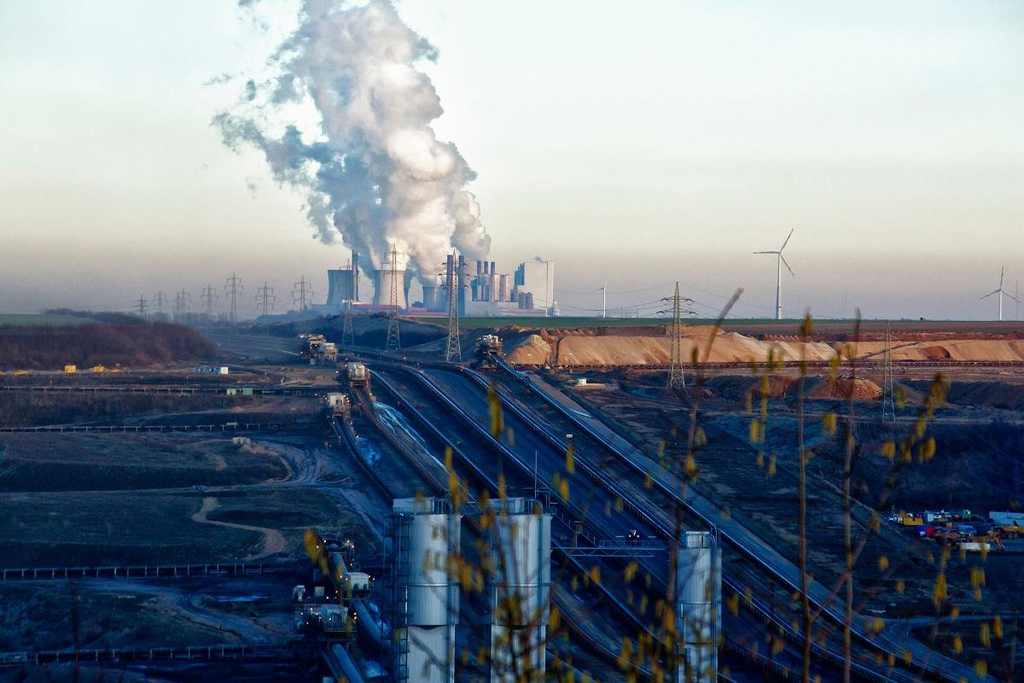

Bert Kaufmann, Garzweiler surface mine, 2012 · Wikimedia Commons, CC BY-SA 2.0.

Brown coal is too wet and cheap to ship, so the plants were built at the mine.

Neither the plant nor the mine is worth much to anyone else.

Plants sign contracts of decades, or share an owner with the mine.

Asset specificity is the value an investment loses outside this relationship. The more it loses, the greater incentives for ownership.

## Uncertainty: what is not known today is decided later

[figure not shown]

Ajay Suresh, Zara storefront, New York, 2019 · Wikimedia Commons, CC BY 2.0.

Zara cannot know in January what will sell in April.

Fast-changing items: made in and near its own Spanish factories, redesigned in weeks.

Basic items: bought from distant suppliers on long lead times.

Uncertainty is how much will need adapting after the deal is made. The more adapting, the more it pays to keep the decision close (esp. when asset are specific).

## Repetition lets a hybrid replace ownership

[figure not shown]

Ocdp, [Denso Takatana plant](https://commons.wikimedia.org/wiki/File:Denso_902.jpg) · Wikimedia Commons, CC0.

Denso was a Toyota division until 1949. Toyota spun it out bought from it ever since.

Toyota built a hybrid relationship: a stake in Denso, shared engineers, shared plans.

Decades of kept promises are why Toyota has never needed to buy Denso back.

Frequency pushes an asset-specific deal toward hierarchy, since repetition makes protecting it worth the cost. But the threat of losing decades of orders keeps both sides honest, so a hybrid can replace hierarchy.

## Place four Apple transactions on Williamson’s bar

1. Memory chips: bought from three suppliers under multiyear agreements.

2. A-series chips: Apple’s design, made by TSMC on capacity reserved for Apple.

3. Apps: written by outside developers, sold in Apple’s store under Apple’s rules.

4. Modems: Qualcomm, then Intel, then Apple bought Intel’s modem unit in 2019.

[figure not shown]

Market, hybrid, or hierarchy? Name the attribute that puts it there.

**3 minutes** · Pairs · Then a show of hands for each

## Hold-up: once the money is sunk, you can be squeezed

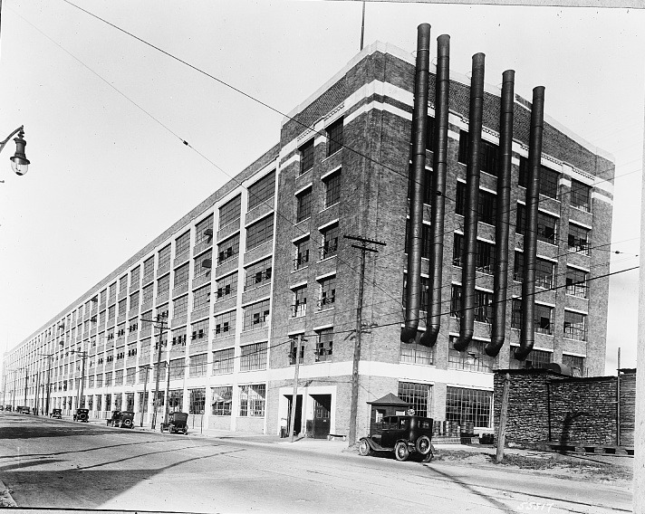

Detroit Publishing Co., [Fisher body plant](https://www.loc.gov/item/2016816985/), c. 1915–1925 · Library of Congress, cropped.

iPhones were built around Qualcomm’s modem, on Qualcomm’s terms. Apple sued in 2017.

GM depended on Fisher Body for car bodies. In 1926 it bought the company.

Once your investment is worth little outside the deal, the other side can squeeze you.

Hold-up is the fear that makes a firm own what it could buy. GM bought Fisher Body in 1926; Apple bought Intel’s modem unit in 2019.

## The firm stops growing where buying is cheaper

[figure not shown]

When buying gets cheaper, the firm does less itself. When organizing gets cheaper, it does more.

# Group Activity: Consider an Economic Relationship in Your Industry

## Choose how to govern one business relationship

1. **Select:** one transaction between a firm in your industry and a partner: a supplier, a distributor, a contract manufacturer, or a licensee.
2. **Diagnose:** the key transaction cost in that relationship: finding, agreeing, or making sure each side complies.
3. **Recommend:** a market contract, a relationship with rules, or ownership.
4. **Defend:** one safeguard your arrangement relies on, and one cost of your choice.

**15 minutes** · Existing industry teams · No additional research

Be ready to report: relationship, transaction cost, arrangement, safeguard and cost.

## Report out

Which transaction cost drove your recommendation, and what did your arrangement give up?

**4 one-minute reports**, then **discussion**

Are there institutions that stands in for a manager? Do they make integration less likely?

## Takeaways

Why do firms exist? Why not one giant firm?

Market transaction costs can be too high, so a manager decides instead. Managing costs something too, so the firm stops expanding where buying is cheaper.

Most deals are hybrids between buying and owning.

Key features of the transaction (specificity, uncertainty, and frequency) shape the degree of integration